# guessing-cliff-d-abschluesse_sc

Eine Studie vergleicht den höchsten Bildungsabschluss zweier Gruppen.

> Schätzen Sie $\text{Cliff's } d = \frac{\#(A_i > B_i) - \#(A_i < B_i)}{\#A \cdot \#B}$

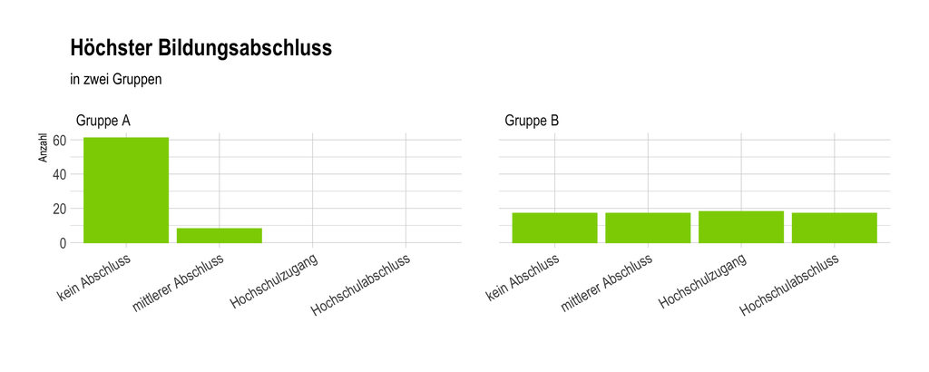

-1-0.7-0.37-0.030.31

Eine Studie vergleicht den höchsten Bildungsabschluss zweier Gruppen.

> Schätzen Sie $\text{Cliff's } d = \frac{\#(A_i > B_i) - \#(A_i < B_i)}{\#A \cdot \#B}$

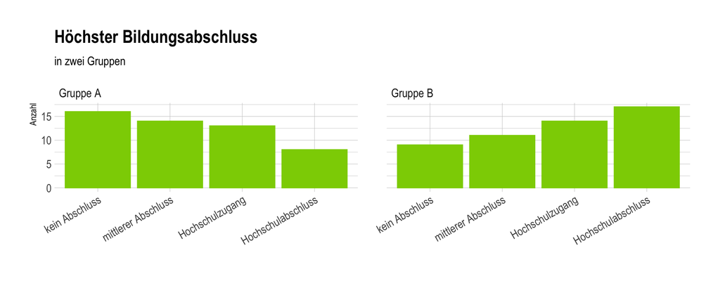

-1-0.93-0.59-0.260.070.410.741

Eine Studie vergleicht den höchsten Bildungsabschluss zweier Gruppen.

> Schätzen Sie $\text{Cliff's } d = \frac{\#(A_i > B_i) - \#(A_i < B_i)}{\#A \cdot \#B}$

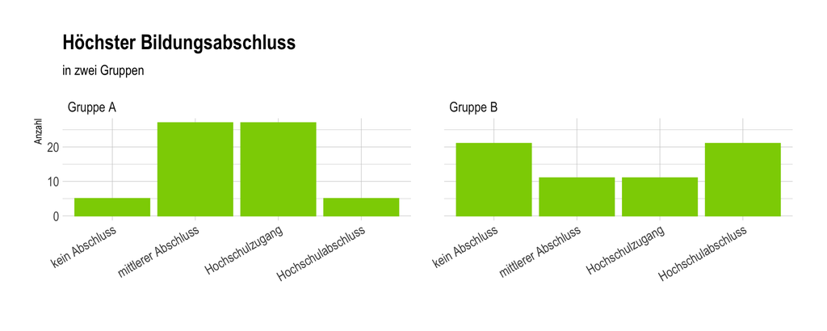

-1-0.67-0.3300.330.671

Eine Studie vergleicht den höchsten Bildungsabschluss zweier Gruppen.

> Schätzen Sie $\text{Cliff's } d = \frac{\#(A_i > B_i) - \#(A_i < B_i)}{\#A \cdot \#B}$

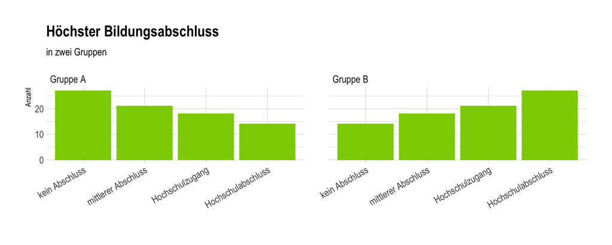

-1-0.93-0.59-0.260.070.410.741

Eine Studie vergleicht den höchsten Bildungsabschluss zweier Gruppen.

> Schätzen Sie $\text{Cliff's } d = \frac{\#(A_i > B_i) - \#(A_i < B_i)}{\#A \cdot \#B}$

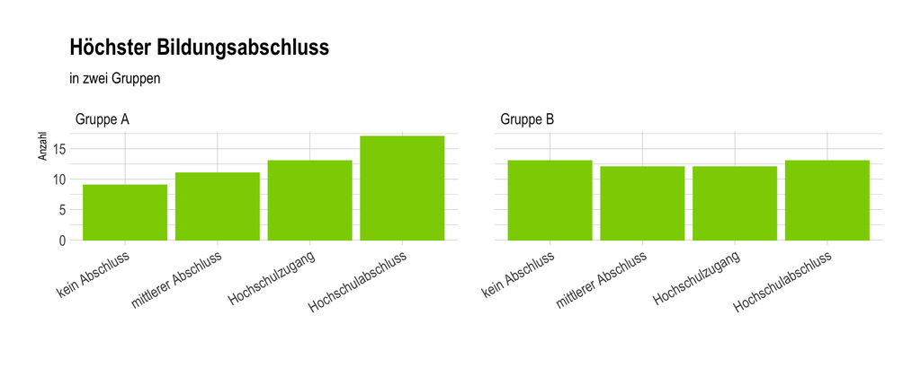

-1-0.87-0.54-0.20.130.460.81

Eine Studie vergleicht den höchsten Bildungsabschluss zweier Gruppen.

> Schätzen Sie $\text{Cliff's } d = \frac{\#(A_i > B_i) - \#(A_i < B_i)}{\#A \cdot \#B}$

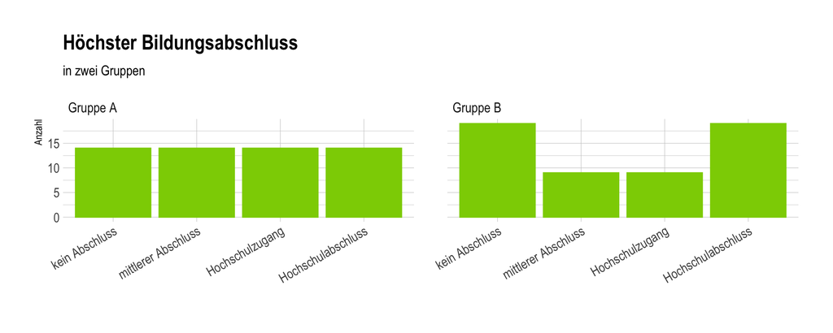

-1-0.67-0.3300.330.671

Eine Studie vergleicht den höchsten Bildungsabschluss zweier Gruppen.

> Schätzen Sie $\text{Cliff's } d = \frac{\#(A_i > B_i) - \#(A_i < B_i)}{\#A \cdot \#B}$

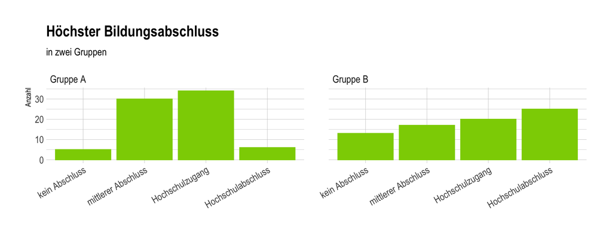

-1-0.81-0.47-0.140.190.530.861

Eine Studie vergleicht den höchsten Bildungsabschluss zweier Gruppen.

> Schätzen Sie $\text{Cliff's } d = \frac{\#(A_i > B_i) - \#(A_i < B_i)}{\#A \cdot \#B}$

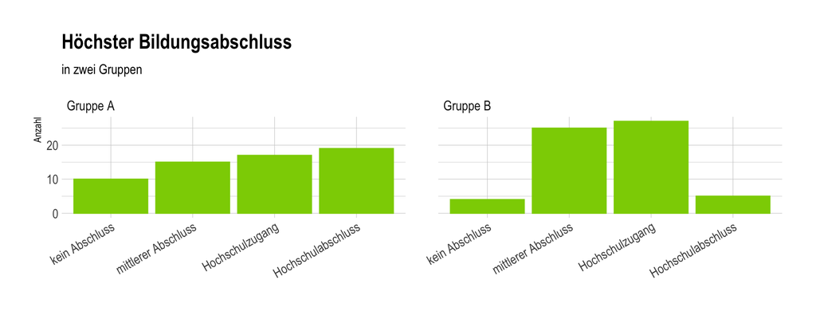

-1-0.87-0.54-0.20.130.460.81

Eine Studie vergleicht den höchsten Bildungsabschluss zweier Gruppen.

> Schätzen Sie $\text{Cliff's } d = \frac{\#(A_i > B_i) - \#(A_i < B_i)}{\#A \cdot \#B}$

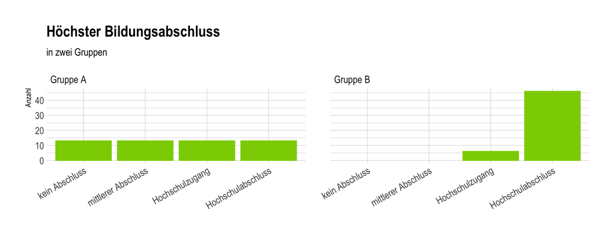

-1-0.69-0.36-0.020.311

Eine Studie vergleicht den höchsten Bildungsabschluss zweier Gruppen.

> Schätzen Sie $\text{Cliff's } d = \frac{\#(A_i > B_i) - \#(A_i < B_i)}{\#A \cdot \#B}$

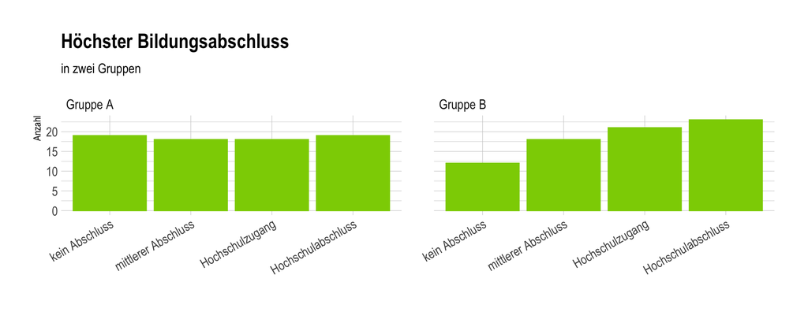

-1-0.79-0.45-0.120.210.550.881

Eine Studie vergleicht den höchsten Bildungsabschluss zweier Gruppen.

> Schätzen Sie $\text{Cliff's } d = \frac{\#(A_i > B_i) - \#(A_i < B_i)}{\#A \cdot \#B}$

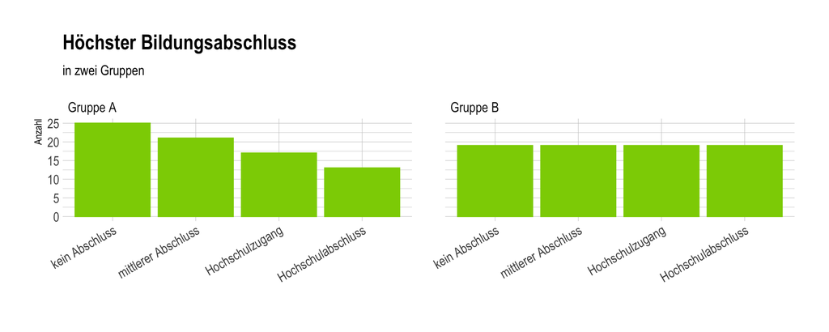

-1-0.8-0.46-0.130.20.540.871

Eine Studie vergleicht den höchsten Bildungsabschluss zweier Gruppen.

> Schätzen Sie $\text{Cliff's } d = \frac{\#(A_i > B_i) - \#(A_i < B_i)}{\#A \cdot \#B}$

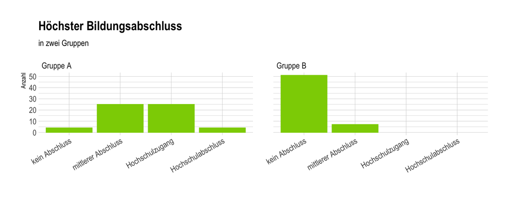

-1-0.130.20.540.871

Eine Studie vergleicht den höchsten Bildungsabschluss zweier Gruppen.

> Schätzen Sie $\text{Cliff's } d = \frac{\#(A_i > B_i) - \#(A_i < B_i)}{\#A \cdot \#B}$

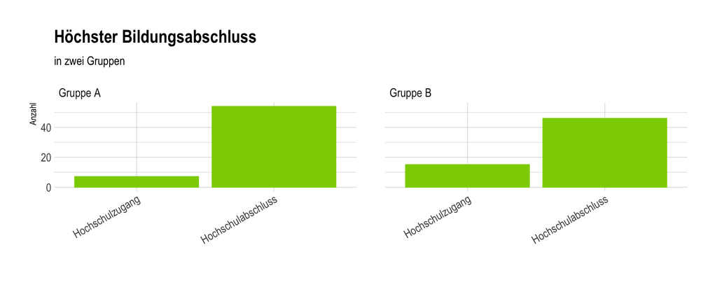

-1-0.87-0.54-0.20.130.460.81

Eine Studie vergleicht den höchsten Bildungsabschluss zweier Gruppen.

> Schätzen Sie $\text{Cliff's } d = \frac{\#(A_i > B_i) - \#(A_i < B_i)}{\#A \cdot \#B}$

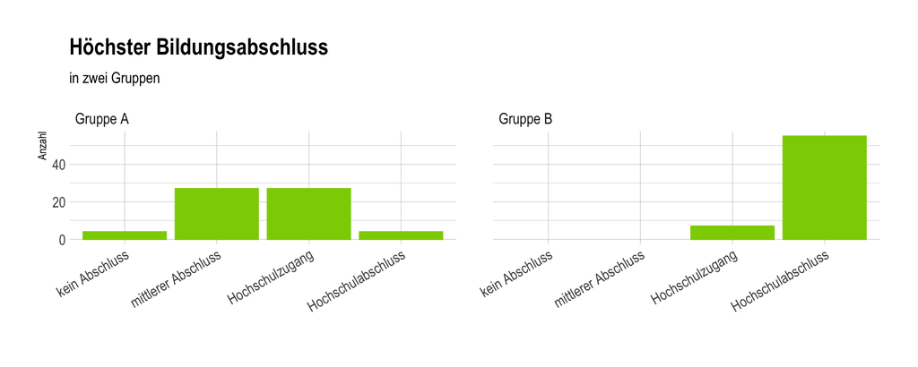

-1-0.88-0.55-0.210.121

Eine Studie vergleicht den höchsten Bildungsabschluss zweier Gruppen.

> Schätzen Sie $\text{Cliff's } d = \frac{\#(A_i > B_i) - \#(A_i < B_i)}{\#A \cdot \#B}$

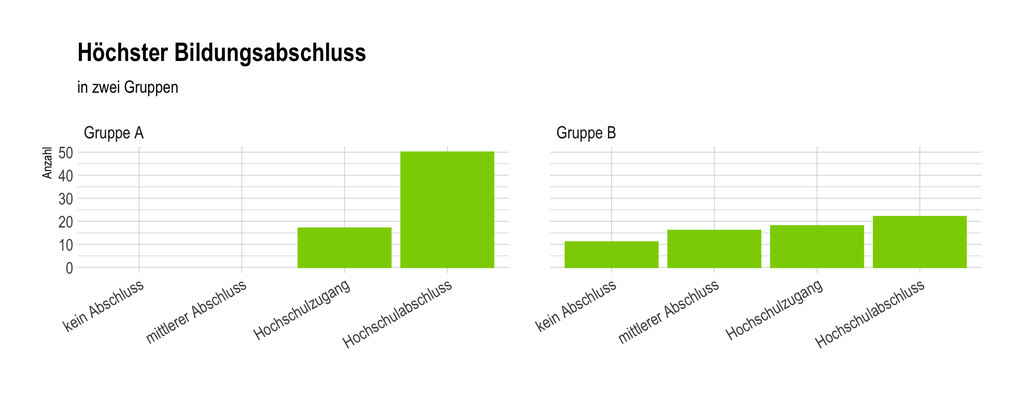

-1-0.48-0.150.190.520.851

Eine Studie vergleicht den höchsten Bildungsabschluss zweier Gruppen.

> Schätzen Sie $\text{Cliff's } d = \frac{\#(A_i > B_i) - \#(A_i < B_i)}{\#A \cdot \#B}$

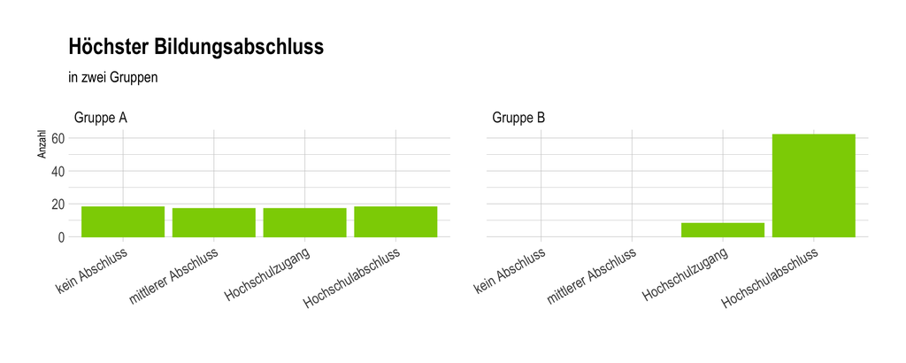

-1-0.69-0.36-0.020.311

Eine Studie vergleicht den höchsten Bildungsabschluss zweier Gruppen.

> Schätzen Sie $\text{Cliff's } d = \frac{\#(A_i > B_i) - \#(A_i < B_i)}{\#A \cdot \#B}$

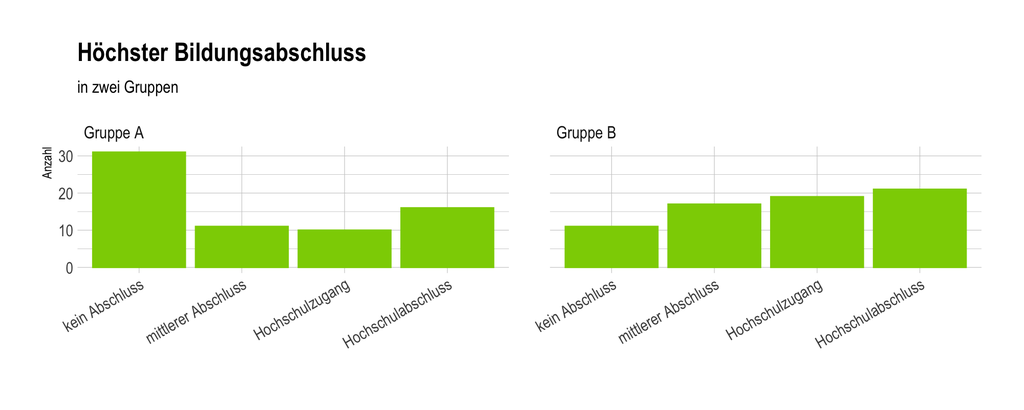

-1-0.94-0.6-0.270.060.40.731

Eine Studie vergleicht den höchsten Bildungsabschluss zweier Gruppen.

> Schätzen Sie $\text{Cliff's } d = \frac{\#(A_i > B_i) - \#(A_i < B_i)}{\#A \cdot \#B}$

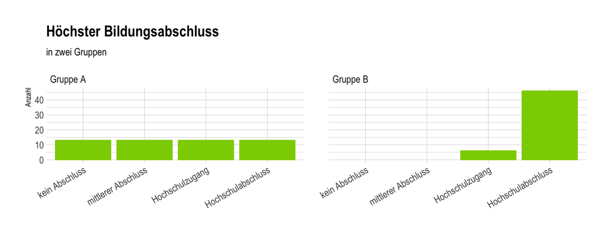

-1-0.69-0.36-0.020.311

Eine Studie vergleicht den höchsten Bildungsabschluss zweier Gruppen.

> Schätzen Sie $\text{Cliff's } d = \frac{\#(A_i > B_i) - \#(A_i < B_i)}{\#A \cdot \#B}$

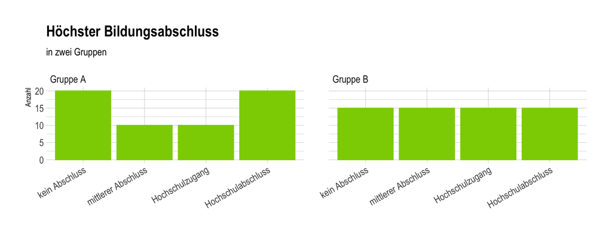

-1-0.67-0.3300.330.671

Eine Studie vergleicht den höchsten Bildungsabschluss zweier Gruppen.

> Schätzen Sie $\text{Cliff's } d = \frac{\#(A_i > B_i) - \#(A_i < B_i)}{\#A \cdot \#B}$

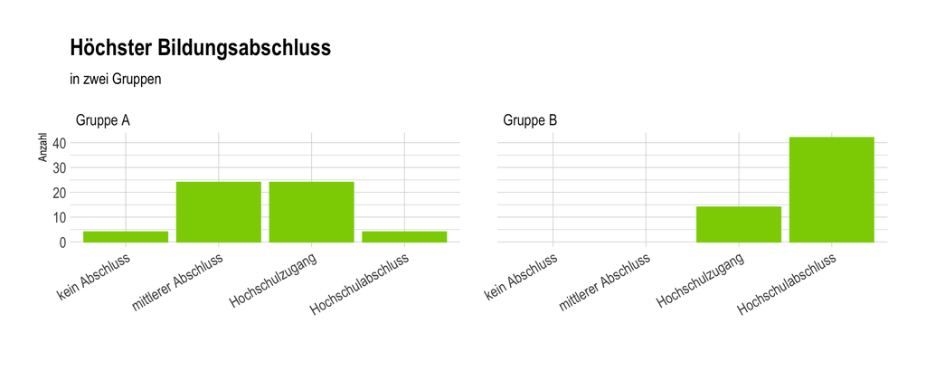

-1-0.8-0.47-0.130.21